# Data Viz Tips & Tricks

Eric Ekholm

CCPS

# About Me

- Data Specialist at CCPS
  - formerly VDOE & MS English Teacher
- PhD in Educational Psychology
- 2 kids, 1 pitbull
- Enjoy data, coding, reading, and crossfit
- [Twitter](https://twitter.com/ekholm_e), [Github](https://github.com/ekholme), [Website](https://www.ericekholm.com), Email

# About These Materials

- All plots created using [R](https://www.r-project.org/) and the [`ggplot2`](https://ggplot2.tidyverse.org/) visualization library
- Slides created using [Quarto](https://quarto.org/)
- Data is publicly available from [VDOE](https://p1pe.doe.virginia.gov/apex_captcha/home.do?apexTypeId=306) (& is also available in this repository).
- All code/slides/data available in this [Github repository](https://github.com/ekholme/data_viz_tips)

# Types of Data Viz

- Generally, there are 2 “types” of data viz we do:
  - Embedded in reports/slides (usually static)
  - Standalone (usually interactive; e.g. a dashboard)
- This presentation is focused on the first (although some principles may apply to the second as well)

# Framing

- Imagine you’re asked to conduct an analysis of your division’s historical performance on the grades 3-8 reading SOLs.

# Overarching Principle: Use Data to Tell a Story

- Embrace the fact that visualizations are subjective
- Make your viz decisions shape the story you want to tell
- Tailor the story you’re telling to the decisions you’re trying to inform

# Tip #1: Tell Viewers the Takeaway

# Generic Title

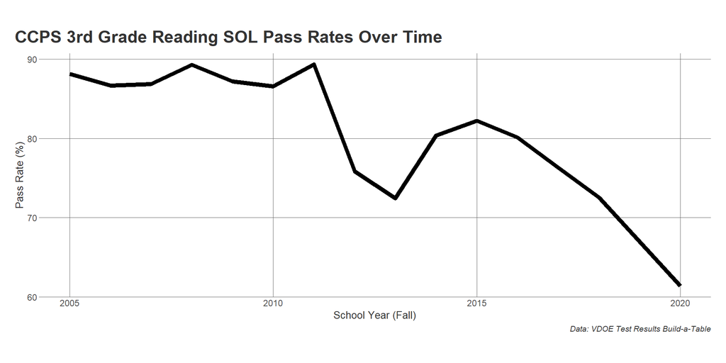

# Opinionated Title

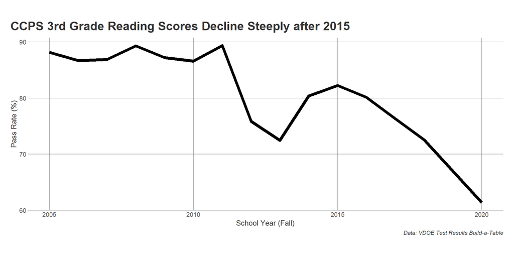

# Discussion

- What are your approaches?
- When might you not want to use this?
- Other thoughts/questions?

# Tip #2: Avoid Extraneous Information

# Too Much

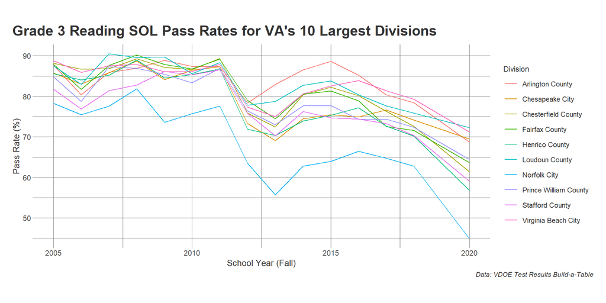

# Just Enough

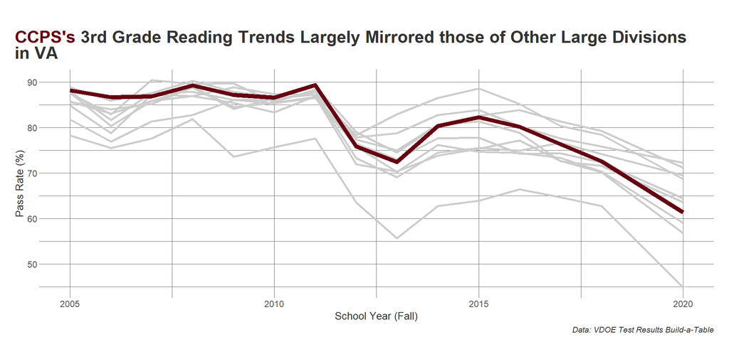

# Discussion

- What are your approaches?
- When might you not want to use this?
- Other thoughts/questions?

# Tip #3: Use Aesthetics that Match Your Story

# Compare to Avg

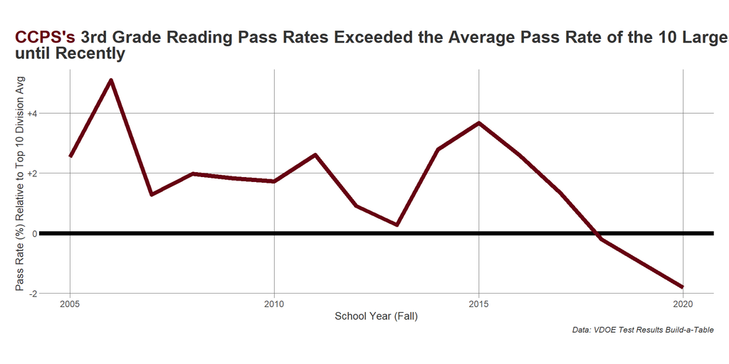

# Compare to Baseline

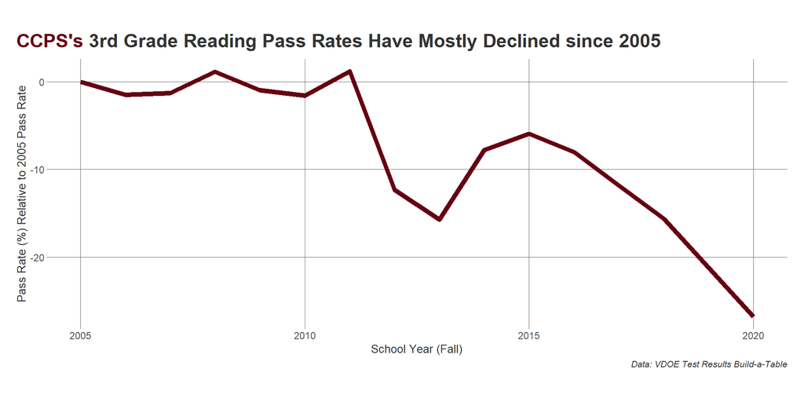

# Compare to Other

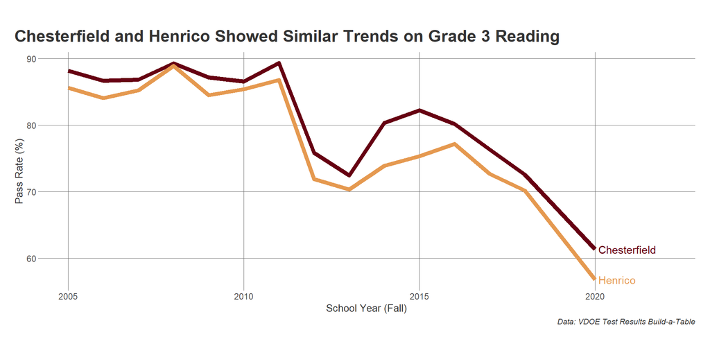

# Compare to Other

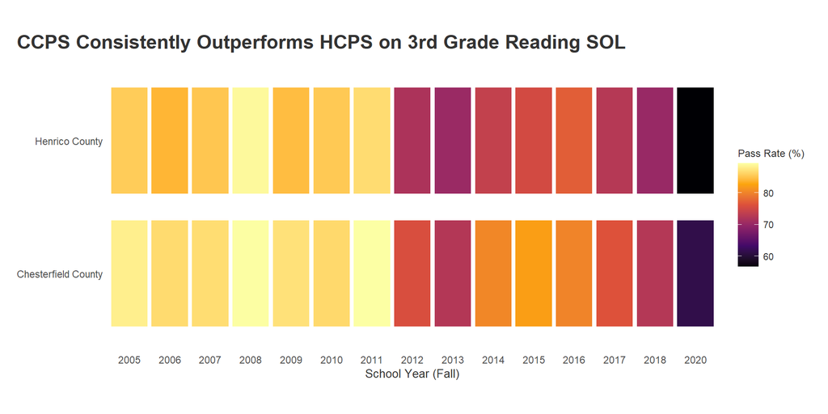

# Discussion

- What are your approaches?
- When might you not want to use this?
- Other thoughts/questions?

# Tip #4: Build to Complex Visuals

- Generally, try to keep visualizations simple and aligned with your key takeaways
- If you need to do something more complex, build to it over several plots

# Start With

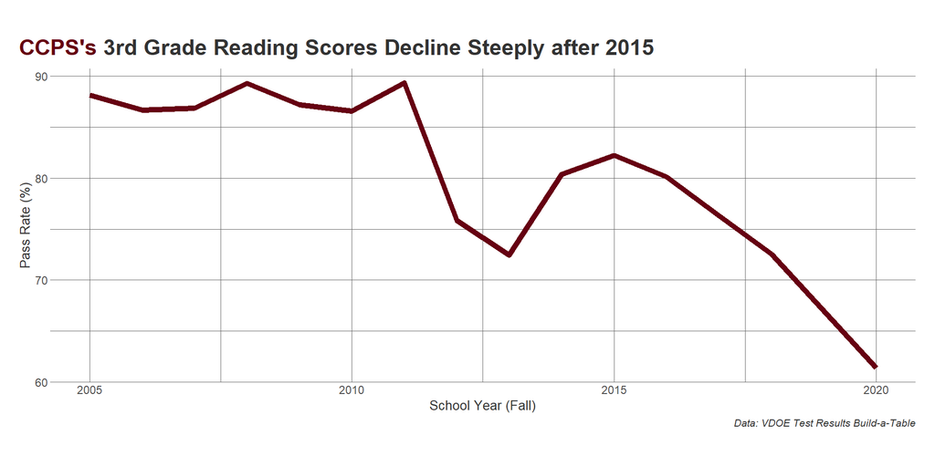

# Then

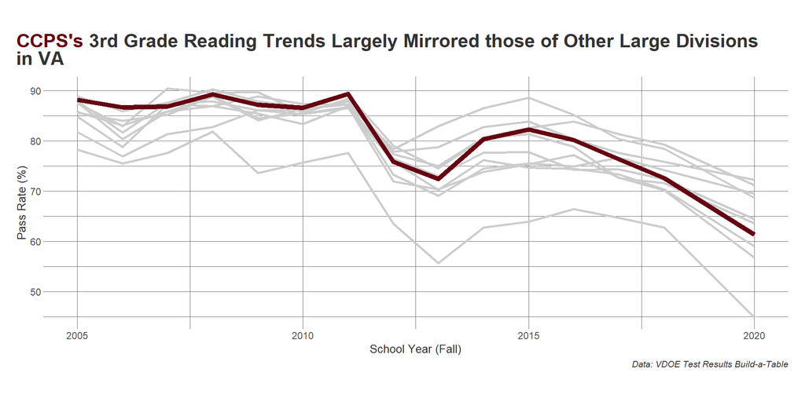

# Finally

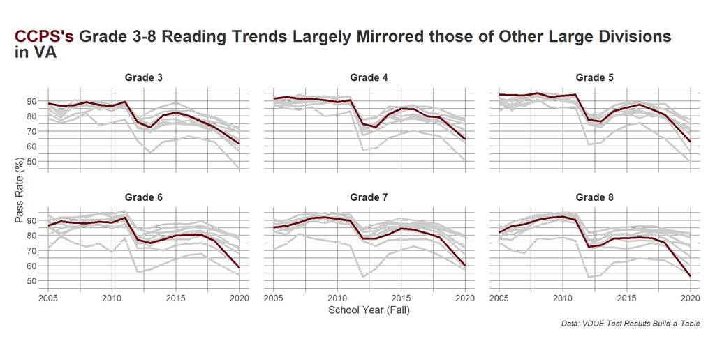

# Discussion

- What are your approaches?
- When might you not want to use this?
- Other thoughts/questions?

# Wrapping Up

- Remember that you are telling a story with your data
- Decisions you make about how to present your data should align with your story
- Less is usually more
- If you need a complex visual, build to it

# Questions?

# Additional Materials

- [Fundamentals of Data Visualization by Claus Wilke](https://clauswilke.com/dataviz/)
- [Data Visualization by Kieran Healy](https://socviz.co/)
- [ggplot2: Elegant Graphics for Data Analysis by Wickham, Navarro, & Pedersen](https://ggplot2-book.org/)